# Package limSolve: solving linear inverse models in R

Karline Soetaert, Karel van den Meersche and Dick van Oevelen

18 November 2022

Abstract

# 1 Introduction

In matrix notation, linear inverse problems are defined as:

$$\begin{align*}
\label{eq:1}
\mathbf{A}\cdot \mathbf{x}\simeq\mathbf{b} \qquad (1)\\
\mathbf{E}\cdot \mathbf{x}=\mathbf{f} \qquad (2)\\
\mathbf{G}\cdot \mathbf{x}\geq\mathbf{h} \qquad (3)
\end{align*}$$

There are three sets of linear equations: equalities that have to be met as closely as possible (1), equalities that have to be met exactly (2) and inequalities (3).

Depending on the active set of equalities (2) and constraints (3), the system may either be underdetermined, even determined, or overdetermined. Solving these problems requires different mathematical techniques.

# 2 Even determined systems

An even determined problem has as many (independent and consistent) equations as unknowns. There is only one solution that satisfies the equations exactly.

Even determined systems that do not comprise inequalities, can be solved with *R* function *solve*, or -more generally- with *limSolve* function *Solve*. The latter is based on the Moore-Penrose generalised inverse method, and can solve any linear system of equations.

In case the model is even determined, and if *E* is square and positive definite, *Solve* returns the same solution as function *solve*. The function uses function *ginv* from package *MASS* (Venables & Ripley, 2002).

Consider the following set of linear equations:

$$\begin{array} {*{20}l}
{3 \cdot x_1} & {+ 2 \cdot x_2} &{+
x_3} &=& 2 \\
{x_1} & {
} &{} &=& 1 \\
{2 \cdot x_1} & {} &{+ 2 \cdot x_3}
&=& 8
\end{array}$$

which, in matrix notation is:
$$\left[ {
\begin{array}{*{3}c}
3 & 2 & 1 \\
1 & 0 & 0 \\
2 & 0 & 2 \\
\end{array}}
\right] \cdot \mathbf{X}
=
\left[
{\begin{array}{*{3}c}
2 \\ 1 \\ 8 \\
\end{array}} \right]$$
where $\mathbf{X} = [x_1,x_2,x_3]^T$.

In *R*, we write:

```r
E <- matrix(nrow = 3, ncol = 3,
            data = c(3, 1, 2, 2, 0, 0, 1, 0, 2))
F <- c(2, 1, 8)

solve(E, F)
```

```
## [1]  1 -2  3
```

```r
Solve(E, F)
```

```
## [1]  1 -2  3
```

In the next example, an additional equation, which is a linear combination of the first two is added to the model (i.e. $eq_4=eq_1+eq_2$).

As one set of equations is redundant, this problem is equivalent to the previous one. It is even determined although it contains 4 equations and only 3 unknowns.

As the input matrix is not square, this model can only be solved with function *Solve*
$$\left[ {
\begin{array}{*{3}c}
3 & 2 & 1 \\
1 & 0 & 0 \\
2 & 0 & 2 \\
4 & 2 & 1 \\
\end{array}}
\right] \cdot \mathbf{X}
=
\left[ {
\begin{array}{*{3}c}
2 \\ 1 \\ 8 \\ 3 \\
\end{array}}
\right]$$

```r
E2 <- rbind(E, E[1, ] + E[2, ])
F2 <- c(F, F[1] + F[2])

#solve(E2,F2) # error 'a' (4 x 3) must be square
Solve(E2, F2)
```

```
## [1]  1 -2  3
```

# 3 Overdetermined systems

Overdetermined linear systems contain more independent equations than unknowns.

In this case, there is only one solution in the least squares sense, i.e. a solution that satisfies:

$$\min\limits_x\| \mathbf{A} \cdot
\mathbf{x} - \mathbf{b} \|^2.$$

The least squares solution can be singled out by function *lsei* (**l**east **s**quares with **e**qualities and **i**nequalities).

If argument *fulloutput* is *TRUE*, this function also returns the parameter covariance matrix, which gives indication on the confidence interval and relations among the estimated unknowns.

## 3.1 Equalities only

If there are no inequalities, then the least squares solution can also be estimated with *Solve*.

The following problem:
$$\left[ {
\begin{array}{*{3}c}
3 & 2 & 1 \\
1 & 0 & 0 \\
2 & 0 & 2 \\
0 & 1 & 0 \\
\end{array}}
\right]
\cdot \mathbf{X}
=
\left[ {
\begin{array}{*{3}c}
2 \\ 1 \\ 8 \\ 3 \\
\end{array}}
\right]$$

is solved in *R* as follows:

```r
E <- matrix(nrow = 4, ncol = 3,
            data = c(3, 1, 2, 0, 2, 0, 0, 1, 1, 0, 2, 0))
F <- c(2, 1, 8, 3)

lsei(A = E, B = F, fulloutput = TRUE, verbose = FALSE)
```

```
## $X
## [1] -1.1621621  0.8378378  4.8918918
##
## $residualNorm
## [1] 0
##
## $solutionNorm
## [1] 10.81081
##
## $IsError
## [1] FALSE
##
## $type
## [1] "lsei"
```

Here the *residualNorm* is the sum of absolute values of the residuals of the equalities that have to be met exactly ($\mathbf{E} \cdot \mathbf{x} = \mathbf{f}$) and of the violated inequalities ($\mathbf{G} \cdot \mathbf{x} \geq \mathbf{h}$). As in this case, there are none of those, this quantity is 0.

Alternatively, the problem can be solved by *Solve*:

```r
Solve(E, F)
```

```
## [1] -1.1621622  0.8378378  4.8918919
```

## 3.2 Equalities and inequalities

If, in addition to the equalities, there are also inequalities, then *lsei* is the only method to find the least squares solution.

With the following inequalities added:
$$\begin{eqnarray*}
x_1 - 2 \cdot x_2 &<& 3 \\
x_1 - x_3 &>& 2
\end{eqnarray*}$$
the R-code becomes:

```r
G <- matrix(nrow = 2, ncol = 3, byrow = TRUE,
            data = c(-1, 2, 0, 1, 0, -1))
H <- c(-3, 2)

lsei(E = E, F = F, G = G, H = H, verbose = FALSE)
```

```
## $X
## [1] -0.8234536 -0.4705453  5.0083641
##
## $residualNorm
## [1] 13.89872
##
## $solutionNorm
## [1] 0.1624794
##
## $IsError
## [1] TRUE
##
## $type
## [1] "lsei"
```

Where the *residualNorm* now includes the violated inequalities ($\mathbf{G} \cdot \mathbf{x} \geq \mathbf{h}$).

Note that the solution will be different if we require the equalities to be only approximately met:

```r
lsei(A = E, B = F, G = G, H = H, verbose = FALSE)
```

```
## $X
## [1]  2.04142012 -0.47928994  0.04142012
##
## $residualNorm
## [1] 0
##
## $solutionNorm
## [1] 38.17751
##
## $IsError
## [1] FALSE
##
## $type
## [1] "lsei"
```

# 4 Underdetermined systems

Underdetermined linear systems contain less independent equations than unknowns. If the equations are consistent, there exist an infinite amount of solutions.

To solve such models, there are several options:

- *ldei* - finds the **l**east **d**istance” (or parsimonious) solution, i.e. the one where the sum of squared unknowns is minimal
- *lsei*- minimises some other set of linear functions ($\mathbf{A}\cdot \mathbf{x} \simeq \mathbf{b}$) in a least squares sense.
- *linp* - finds the solution where *one* linear function (i.e. the sum of flows) is either minimized (a “cost” function) or maximized (a “profit” function). Uses linear programming.
- *xranges* - finds the possible ranges ([min,max]) for each unknown.
- *xsample* - randomly samples the solution space in a Bayesian way. This method returns the conditional probability density function for each unknown (Meersche et al., 2009).

## 4.1 Equalities only

We start with an example including only equalities.

$$\begin{array} {*{20}l}
{3 \cdot x_1} & {+ 2 \cdot x_2} &{+
x_3} &=& 2 \\
{x_1} & { } &{} &=& 1
\end{array}$$

Functions *Solve* and *ldei* retrieve the *parsimonious* solution, i.e. the solution for which $\sum x_i^2$ is minimal.

```r
E <- matrix(nrow = 2, ncol = 3,
            data = c(3, 1, 2, 0, 1, 0))
F <- c(2, 1)

Solve(E, F)
```

```
## [1]  1.0 -0.4 -0.2
```

```r
ldei(E = E, F = F)$X
```

```
## [1]  1.0 -0.4 -0.2
```

It is slightly more complex to select the parsimonious solution using *lsei*. Here the approximate equations (*A*, the identity matrix, and *b*) have to be specified.

```r
lsei(E = E, F = F, A = diag(3), B = rep(0, 3), verbose = FALSE)$X
```

```
## [1]  1.0 -0.4 -0.2
```

It is also possible to *randomly sample* the solution space. This demonstrates that all valid solutions of $x_2$ and $x_3$ are located on a line (figure @ref(fig:u1b)).

```r
xs <- xsample(E = E, F = F, iter = 500)$X
```

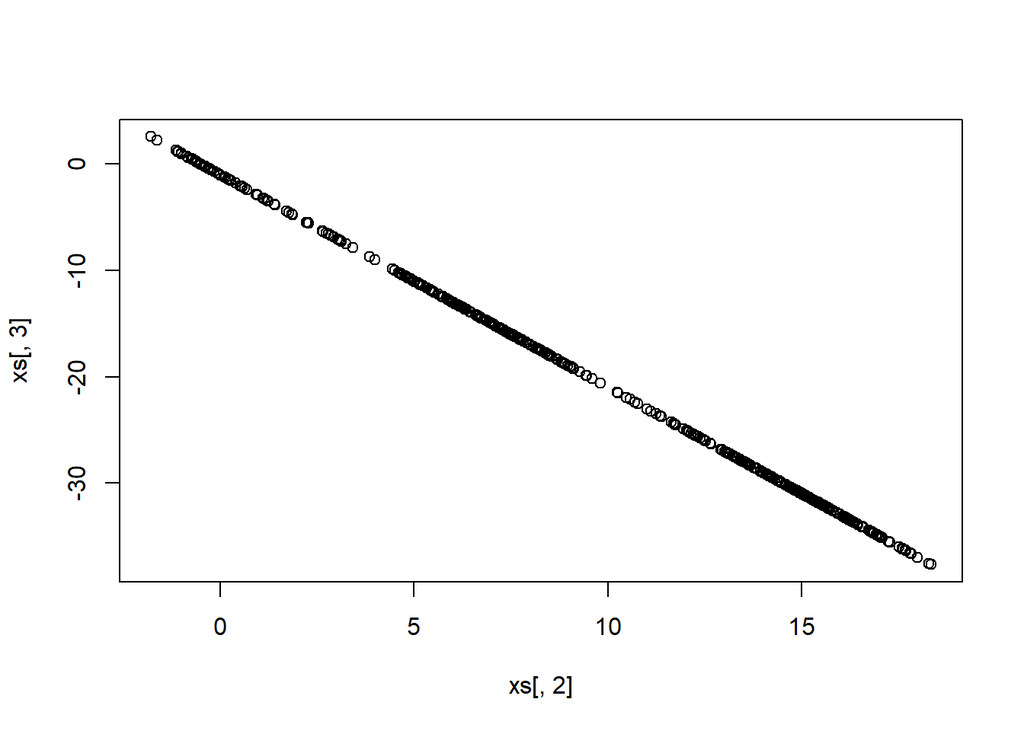

Fig: Random sample of the underdetermined system including only equalities.

```r
plot(xs[ ,2], xs[ ,3])
```

## 4.2 Equalities and inequalities

Consider the following set of linear equations:

$$\begin{array} {*{20}l}
{3 \cdot x_1} & {+ 2 \cdot x_2} &{+ x_3} &{+ 4
\cdot x_4} &=& 2 \\
{x_1} & {+ x_2 } &{+ x_3} &{+
x_4} &=& 2
\end{array}$$

complemented with the inequalities:

$$\begin{array} {*{20}l}
{2 \cdot x_1} & {+ x_2} &{+ x_3} &{+
x_4} &\geq& -1 \\
{-1 \cdot x_1}& {+ 3 \cdot x_2} &{+ 2 \cdot x_3} &{+
x_4} &\geq& 2 \\
{-1 \cdot x_1} & {} &{+ x_3} &{}
&\geq& 1 \\
\end{array}$$

As before, the *parsimonious* solution (that minimises the sum of squared flows) can be found by functions *ldei* and *lsei*.

```r
E <- matrix(ncol = 4, byrow = TRUE,
            data = c(3, 2, 1, 4, 1, 1, 1, 1))
F <- c(2, 2)

G <-matrix(ncol = 4, byrow = TRUE,
           data = c(2, 1, 1, 1, -1, 3, 2, 1, -1, 0, 1, 0))
H <- c(-1, 2, 1)
ldei(E, F, G = G, H = H)$X
```

```
## [1]  0.2  0.8  1.4 -0.4
```

```r
pars <- lsei(E, F, G = G, H = H, A = diag(nrow = 4), B = rep(0, 4))$X
pars
```

```
## [1]  0.2  0.8  1.4 -0.4
```

We can also estimate the *ranges* (minimal and maximal values) of all unknowns using function *xranges*.

```r
(xr <- xranges(E, F, G = G, H = H))
```

```
##        min  max
## [1,] -3.00 0.80
## [2,] -6.75 7.50
## [3,] -2.00 7.50
## [4,] -0.50 4.25
```

The results are conveniently plotted using *R* function *dotchart* (figure @ref(fig:dc)). We plot the parsimonious solution as a point, the range as a horizontal line.

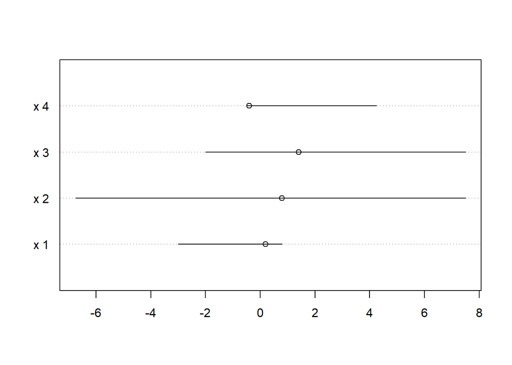

Fig: Parsimonious solution and ranges of the underdetermined system including equalities and inequalities.

```r
dotchart(pars, xlim = range(c(pars,xr)), label = paste("x", 1:4, ""))
segments(x0 = xr[ ,1], x1 = xr[ ,2], y0 = 1:nrow(xr), y1 = 1:nrow(xr))
```

A *random sample* of the infinite amount of solutions is generated by function *xsample* (Meersche et al., 2009). For small problems, the coordinates directions algorithm (“cda”) is a good choice.

```r
xs <- xsample(E = E, F = F, G = G, H = H, type = "cda")$X
```

To visualise its output, we use *R* function *pairs*, with a density function on the diagonal, and without plotting the upper panel (figure @ref(fig:u2)).

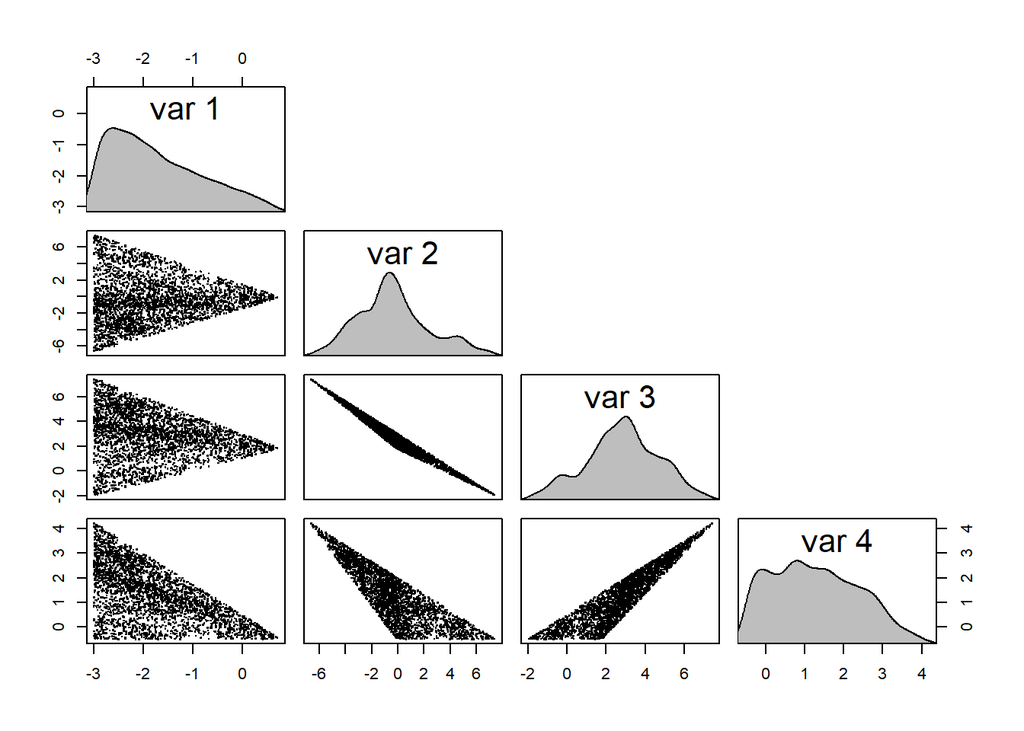

Fig: Random sample of the underdetermined system including equalities and inequalities.

```r
panel.dens <- function(x, ...) {
    USR <- par("usr")
    on.exit(par(usr = USR))
    par(usr = c(USR[1:2], 0, 1.5) )
    DD    <- density(x)
    DD$y  <- DD$y/max(DD$y)
    polygon(DD, col = "grey")
}
xs <- xsample(E = E, F = F, G = G, H = H,
              jmp = 0.5, sdB = 1)$X
pairs(xs, pch = ".", cex = 2,
      upper.panel = NULL, diag.panel = panel.dens)
```

Assume that we define the following variable:
$$v_1=x_1+2 \cdot x_2 - x_3 +x_4 +2$$

We can use functions *varranges* and *varsample* to estimate its ranges and create a random sample respectively.

Variables are written as a matrix equation:
$$\mathbf{Va}\cdot
\mathbf{x}=\mathbf{Vb}$$

```r
Va <- c(1, 2, -1, 1)
Vb <- -2
varranges(E, F, G = G, H = H, EqA = Va, EqB = Vb)
```

```
##         min  max
## [1,] -17.75 15.5
```

```r
summary(varsample(xs, EqA = Va, EqB = Vb))
```

```
##        V1
##  Min.   :-17.416
##  1st Qu.: -6.450
##  Median : -2.275
##  Mean   : -1.981
##  3rd Qu.:  1.660
##  Max.   : 15.321
```

## 4.3 Equalities, inequalities and approximate equations

The following problem

$$\begin{array} {*{50}l}
{3 \cdot x_1} & {+ 2 \cdot x_2} &{+ x_3} &{+ 4
\cdot x_4} &=& 2 \\
{x_1} & {+ x_2 } &{+ x_3} &{+
x_4} &=& 2 \\
\\
{2 \cdot x_1} & {+ x_2} &{+ x_3} &{+ x_4}
&\geq& -1 \\
{-1 \cdot x_1}& {+ 3 \cdot x_2} &{+ 2 \cdot x_3} &{+
x_4} &\geq& 2 \\
{-1 \cdot x_1} & {} &{+ x_3} &{}
&\geq& 1 \\
\\
{2 \cdot x_1} & {+2 \cdot x_2} &{+ x_3} &{+6
\cdot x_4} &\simeq&1 \\
{x_1} & {- x_2} &{+ x_3} &{- x_4}
&\simeq&2
\end{array}$$

is implemented and solved in *R* as:

```r
A <- matrix(ncol = 4, byrow = TRUE,
            data = c(2, 2, 1, 6, 1, -1, 1, -1))
B <- c(1, 2)

lsei(E, F, G = G, H = H, A = A, B = B)$X
```

```
## [1]  0.3333333  0.3333333  1.6666667 -0.3333333
```

Function *xsample* randomly samples the underdetermined problem (using the metropolis algorithm), selecting likely values given the approximate equations. The probability distribution of the latter is assumed Gaussian, with given standard deviation (argument *sdB*, here assumed 1). (Meersche et al., 2009)

The jump length (argument *jmp*) is finetuned such that a sufficient number of trials (~30%), but not too many, is accepted. Note how the ultimate distribution is determined both by the inequality constraints (the sharp edges) as well as by the approximate equations (figure @ref(fig:u3)).

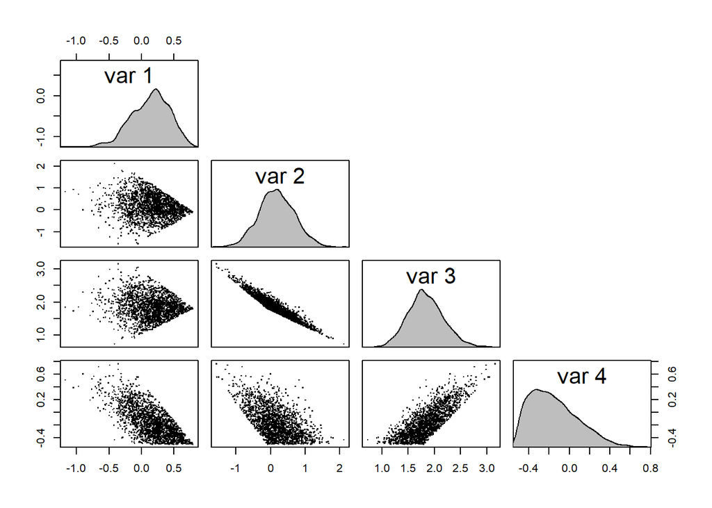

Fig: Random sample of the underdetermined system including equalities, inequalities, and approximate equations

```r
xs <- xsample(E = E, F = F, G = G, H = H, A = A, B = B,
              jmp = 0.5, sdB = 1)$X
pairs(xs, pch = ".", cex = 2,
      upper.panel = NULL, diag.panel = panel.dens)
```

## 4.4 Equalities and inequalities and a target function

Another way to single out one solution out of the infinite amount of valid solutions is by minimising or maximising a linear target function, using linear programming. For instance,

$$\min(x_1 + 2 \cdot x_2 - 1 \cdot x_3 + 4 \cdot x_4)$$

subject to :

$$\begin{array} {*{50}l}
{3 \cdot x_1} & {+ 2 \cdot x_2} &{+ x_3} &{+ 4
\cdot x_4} &=& 2 \\
{x_1} & {+ x_2 } &{+ x_3} &{+
x_4} &=& 2\\
\\
{2 \cdot x_1} & {+ x_2} &{+ x_3} &{+ x_4}
&\geq& -1 \\
{-1 \cdot x_1}& {+ 3 \cdot x_2} &{+ 2 \cdot x_3} &{+
x_4} &\geq& 2 \\
{-1 \cdot x_1} & {} &{+ x_3} &{} &\geq& 1
\\
\\
x_i &\geq& 0 \qquad \forall i \\
\end{array}$$

is implemented in *R* as:

```r
E <- matrix(ncol = 4, byrow = TRUE,
            data = c(3, 2, 1, 4, 1, 1, 1, 1))
F <- c(2, 2)

G <-matrix(ncol = 4, byrow = TRUE,
           data = c(2, 1, 1, 1, -1, 3, 2, 1, -1, 0, 1, 0))
H <- c(-1, 2, 1)
Cost <- c(1, 2, -1, 4)
linp(E, F, G, H, Cost)
```

```
## $X
## [1] 0 0 2 0
##
## $residualNorm
## [1] 0
##
## $solutionNorm
## [1] -2
##
## $IsError
## [1] FALSE
##
## $type
## [1] "linp"
```

The positivity requirement ($x_i \geq 0$) is -by default- part of the linear programming problem, unless it is toggled off by setting argument *ispos* equal to *FALSE*.

```r
LP <- linp(E = E, F = F, G = G, H = H, Cost = Cost, ispos = FALSE)
LP$X
```

```
## [1] -3.00 -6.75  7.50  4.25
```

```r
LP$solutionNorm
```

```
## [1] -7
```

# 5 solving sets of linear equations with sparse matrices

*limSolve* contains special-purpose solvers to efficiently solve linear systems of equations $A x=B$ where the nonzero elements of matrix *A* are located near the diagonal.

They include:

- *Solve.tridiag* when the A matrix is tridiagonal. i.e. the non-zero elements are on the diagonal, below and above the diagonal.
- *Solve.banded* when the A matrix has nonzero elements in bands on, above and below the diagonal.
- *Solve.block* when the A matrix is block-diagonal.

## 5.1 solve, Solve.tridiag, Solve.banded

In the code below, a tridiagonal matrix is created first, and solved with the default *R* method *Solve*, followed by the banded matrix solver *Solve.band*, and the tridiagonal solver *Solve.tridiag*.

The A matrix contains 500 rows and 500 columns, and the problem is solved for 10 different vectors B.

We start by defining the non-zero bands on (*bb*), below (*aa*) and above (*cc*) the diagonal, required for input to the tridiagonal solver; we prepare the full matrix *A* necessary for the default solver and the banded matrix *abd*, required for the banded solver.

```r
nn   <- 500
```

Input for the tridiagonal system:

```r
aa <- runif(nn-1)
bb <- runif(nn)
cc <- runif(nn-1)
```

The full matrix has the nonzero elements on, above and below the diagonal

```r
A <-matrix(nrow = nn, ncol = nn, data = 0)
A [cbind((1:(nn-1)),(2:nn))] <- cc
A [cbind((2:nn),(1:(nn-1)))] <- aa
diag(A) <- bb
```

The banded matrix representation is more compact; the elements above and below the diagonal need padding with $0$:

```r
abd <- rbind(c(0,cc), bb, c(aa,0))
```

Parts of the input are:

```r
A[1:5, 1:5]
```

```
##           [,1]      [,2]      [,3]      [,4]      [,5]
## [1,] 0.2032876 0.4096673 0.0000000 0.0000000 0.0000000
## [2,] 0.7991304 0.6906181 0.3154785 0.0000000 0.0000000
## [3,] 0.0000000 0.8084438 0.6338870 0.8937365 0.0000000
## [4,] 0.0000000 0.0000000 0.5001466 0.1157699 0.6570185
## [5,] 0.0000000 0.0000000 0.0000000 0.7417113 0.8086354
```

```r
aa[1:5]
```

```
## [1] 0.7991304 0.8084438 0.5001466 0.7417113 0.5908795
```

```r
bb[1:5]
```

```
## [1] 0.2032876 0.6906181 0.6338870 0.1157699 0.8086354
```

```r
cc[1:5]
```

```
## [1] 0.40966728 0.31547846 0.89373654 0.65701855 0.05720321
```

```r
abd[ ,1:5]
```

```
##         [,1]      [,2]      [,3]      [,4]      [,5]
##    0.0000000 0.4096673 0.3154785 0.8937365 0.6570185
## bb 0.2032876 0.6906181 0.6338870 0.1157699 0.8086354
##    0.7991304 0.8084438 0.5001466 0.7417113 0.5908795
```

The right hand side consists of 10 vectors:

```r
B <- runif(nn)
B <- cbind(B, 2*B, 3*B, 4*B, 5*B, 6*B, 7*B, 8*B, 9*B, 10*B)
```

The problem is then solved using the three different solvers. The duration of the computation is estimated and printed in milliseconds. “print(system.time()*1000)” does this.

```r
print(system.time(
      Full <- solve(A, B) )
     *1000)
```

```
##    user  system elapsed
##      30       0      30
```

```r
print(system.time(
      Band <- Solve.banded(abd, nup = 1, nlow = 1, B))
      *1000)
```

```
##    user  system elapsed
##       0       0       0
```

```r
print(system.time(
      tri  <- Solve.tridiag(aa, bb, cc, B))
      *1000)
```

```
##    user  system elapsed
##       0       0       0
```

The solvers return 10 solution vectors X, one for each right-hand side; we show the first 5:

```r
Full[1:5, 1:5]
```

```
##               B
## [1,] -0.6528887 -1.30577750 -1.9586662 -2.6115550 -3.264444
## [2,]  1.1927315  2.38546299  3.5781945  4.7709260  5.963657
## [3,] -0.0398406 -0.07968119 -0.1195218 -0.1593624 -0.199203
## [4,] -0.9998669 -1.99973377 -2.9996007 -3.9994675 -4.999334
## [5,]  1.3609097  2.72181943  4.0827292  5.4436389  6.804549
```

Comparison of the different solutions (here only for the second vector) show that they yield the same result.

```r
head(cbind(Full=Full[,2],Band=Band[,2], Tri=tri[,2]))
```

```
##             Full        Band         Tri
## [1,] -1.30577750 -1.30577750 -1.30577750
## [2,]  2.38546299  2.38546299  2.38546299
## [3,] -0.07968119 -0.07968119 -0.07968119
## [4,] -1.99973377 -1.99973377 -1.99973377
## [5,]  2.72181943  2.72181943  2.72181943
## [6,]  0.81097563  0.81097563  0.81097563
```

## 5.2 Banded matrices in the Matrix package

The same can be done with functions from R-package *Matrix* (Bates et al., 2023).

To create the tridiagonal matrix, the position of the non-zero bands relative to the diagonal must be specified; *k = -1:1* sets this to one band below, the band on and one band above the diagonal. The non-zero bands (*diag*) are then inputted as a *list*.

Solving the linear system this way is only slightly slower. However, Matrix provides many more functions operating on sparse matrices than does *limSolve* !.

```
SpMat <- bandSparse(nn, nn, k = -1:1, diag = list(aa, bb, cc))
Tri  <- solve(SpMat, B)
```

## 5.3 Solve.block

A block diagonal system is one where the nonzero elements are in “blocks” near the diagonal.

For the following A-matrix:

$$\left[ {
\begin{array}{*{13}c}
0.0 &-0.98& -0.79&
-0.15& & & & & & & & & Top
\\
-1.00 & 0.25&
-0.87& 0.35& & & & & & & & & Top
\\
0.78 & 0.31& -0.85& 0.89& -0.69& -0.98&
-0.76&
-0.82& & & & & blk1\\
0.12 &-0.01& 0.75& 0.32& -1.00& -0.53&
-0.83&
-0.98& & & & & \\
-0.58 & 0.04& 0.87& 0.38& -1.00& -0.21&
-0.93&
-0.84& & & & & \\
-0.21 &-0.91& -0.09& -0.62& -1.99& -1.12&
-1.21& 0.07& & & & & \\
& & & & 0.78& -0.93&
-0.76& 0.48& -0.87& -0.14& -1.00&
-0.59& blk2\\
& & & & -0.99& 0.21&
-0.73& -0.48& -0.93& -0.91& 0.10&
-0.89& \\
& & & & -0.68& -0.09&
-0.58& -0.21& 0.85& -0.39& 0.79&
-0.71& \\
& & & & 0.39& -0.99&
-0.12& -0.75& -0.68& -0.99& 0.50&
-0.88& \\
& & & & & & & & 0.71&
-0.64& 0.0 & 0.48& Bot \\
& & & & & & & & 0.08&
100.0& 50.00& 15.00& Bot \\
\end{array}
}
\right]$$

```r
#  0.0  -0.98 -0.79 -0.15                                                  Top
# -1.00  0.25 -0.87  0.35                                                  Top
#  0.78  0.31 -0.85  0.89 -0.69 -0.98 -0.76 -0.82                          blk1
#  0.12 -0.01  0.75  0.32 -1.00 -0.53 -0.83 -0.98
# -0.58  0.04  0.87  0.38 -1.00 -0.21 -0.93 -0.84
# -0.21 -0.91 -0.09 -0.62 -1.99 -1.12 -1.21  0.07
#                          0.78 -0.93 -0.76  0.48 -0.87 -0.14 -1.00 -0.59  blk2
#                         -0.99  0.21 -0.73 -0.48 -0.93 -0.91  0.10 -0.89
#                         -0.68 -0.09 -0.58 -0.21  0.85 -0.39  0.79 -0.71
#                          0.39 -0.99 -0.12 -0.75 -0.68 -0.99  0.50 -0.88
#                                                  0.71 -0.64  0.0   0.48  Bot
#                                                  0.08 100.0 50.00 15.00  Bot
```

and the right hand side:

```r
B <- c(-1.92, -1.27, -2.12, -2.16, -2.27, -6.08,
       -3.03, -4.62, -1.02, -3.52, 0.55, 165.08)
```

The input to the block diagonal solver is as:.

```r
Top  <- matrix(nrow = 2, ncol = 4, byrow = TRUE, data =
   c( 0.0,  -0.98, -0.79, -0.15, -1.00,  0.25, -0.87,  0.35))

Bot  <- matrix(nrow = 2, ncol = 4, byrow = TRUE, data =
   c( 0.71, -0.64,   0.0,  0.48,  0.08, 100.0, 50.00, 15.00))

Blk1 <- matrix(nrow = 4, ncol = 8, byrow = TRUE, data =
   c( 0.78,  0.31, -0.85,  0.89, -0.69, -0.98, -0.76, -0.82,
      0.12, -0.01,  0.75,  0.32, -1.00, -0.53, -0.83, -0.98,
     -0.58,  0.04,  0.87,  0.38, -1.00, -0.21, -0.93, -0.84,
     -0.21, -0.91, -0.09, -0.62, -1.99, -1.12, -1.21,  0.07))

Blk2 <- matrix(nrow = 4, ncol = 8, byrow = TRUE, data =
    c( 0.78, -0.93, -0.76,  0.48, -0.87, -0.14, -1.00, -0.59,
      -0.99,  0.21, -0.73, -0.48, -0.93, -0.91,  0.10, -0.89,
      -0.68, -0.09, -0.58, -0.21,  0.85, -0.39,  0.79, -0.71,
       0.39, -0.99, -0.12, -0.75, -0.68, -0.99,  0.50, -0.88))
AR <- array(dim = c(4,8,2), data = c(Blk1, Blk2))

AR
```

```
## , , 1
##
##       [,1]  [,2]  [,3]  [,4]  [,5]  [,6]  [,7]  [,8]
## [1,]  0.78  0.31 -0.85  0.89 -0.69 -0.98 -0.76 -0.82
## [2,]  0.12 -0.01  0.75  0.32 -1.00 -0.53 -0.83 -0.98
## [3,] -0.58  0.04  0.87  0.38 -1.00 -0.21 -0.93 -0.84
## [4,] -0.21 -0.91 -0.09 -0.62 -1.99 -1.12 -1.21  0.07
##
## , , 2
##
##       [,1]  [,2]  [,3]  [,4]  [,5]  [,6]  [,7]  [,8]
## [1,]  0.78 -0.93 -0.76  0.48 -0.87 -0.14 -1.00 -0.59
## [2,] -0.99  0.21 -0.73 -0.48 -0.93 -0.91  0.10 -0.89
## [3,] -0.68 -0.09 -0.58 -0.21  0.85 -0.39  0.79 -0.71
## [4,]  0.39 -0.99 -0.12 -0.75 -0.68 -0.99  0.50 -0.88
```

The blocks overlap with 4 columns; the system is solved as:

```r
overlap <- 4
Solve.block(Top, AR, Bot, B, overlap=4)
```

```
##       [,1]
##  [1,]    1
##  [2,]    1
##  [3,]    1
##  [4,]    1
##  [5,]    1
##  [6,]    1
##  [7,]    1
##  [8,]    1
##  [9,]    1
## [10,]    1
## [11,]    1
## [12,]    1
```

Without much loss of speed, this system can be solved for several right-hand sides; here we do this for 1000 (!) *B*-values

```r
B3 <- B
for (i in 2:1000) B3 <- cbind(B3, B*i)

print(system.time(
  X <- Solve.block(Top, AR, Bot, B3, overlap = 4))
  *1000)
```

```
##    user  system elapsed
##       0       0       0
```

```r
X[,c(1, 10, 100, 1000)]
```

```
##       [,1] [,2] [,3] [,4]
##  [1,]    1   10  100 1000
##  [2,]    1   10  100 1000
##  [3,]    1   10  100 1000
##  [4,]    1   10  100 1000
##  [5,]    1   10  100 1000
##  [6,]    1   10  100 1000
##  [7,]    1   10  100 1000
##  [8,]    1   10  100 1000
##  [9,]    1   10  100 1000
## [10,]    1   10  100 1000
## [11,]    1   10  100 1000
## [12,]    1   10  100 1000
```

Note: This implementation of block diagonal matrices differs from the implementation in the *Matrix* package.

# 6 datasets

There are five example applications in package *limSolve*:

- *Blending*. In this underdetermined problem, an optimal composition of a feeding mix is sought such that production costs are minimised subject to minimal nutrient constraints. The problem consists of one equality and 4 inequality conditions, and a cost function. It is solved by linear programming (*linp*). Feasible ranges are estimated (*xranges*) and feasible solutions generated (*xsample*)
- *Chemtax*. This is an overdetermined linear inverse problem, where the algal composition of a (field) sample is estimated based on (experimentally-determined) pigment biomarkers (Mackey et al., 1996). See also *R*-package *BCE* (Meersche et al., 2008). The problem contains 8 unknowns; it consists of 1 equality, 12 approximate equations, and 8 inequalities. It is solved using *lsei* and *xsample*.
- *Minkdiet*. This is another -underdetermined- compositional estimation problem, where the diet composition of Southeast Alaskan Mink is estimated, based on the C and N isotopic ratios of Mink and of its prey items (Ben-David et al., 1997). The problem consists of 7 unknowns, 3 equations, and 7 inequalities
- *RigaWeb*. This is a food web problem, where food web flows of the Gulf of Riga planktonic food web in Spring are quantified (Donali et al., 1999). This underdetermined model comprises 26 unknowns, 14 equalities, and 45 inequalities. It is solved by *lsei*, *xranges*, and *xsample*.
- *E_coli*. This is a flux balance problem, estimating the core metabolic fluxes of Escherichia coli (Edwards et al., 2002). It is the largest example included in *limSolve*. There are 70 unknowns, 54 equalities and 62 inequalities, and one function to maximise. This model is solved using *lsei*, *linp*, *xranges*, and *xsample*. Note that this problem is quite difficult to solve; it may not solve on all platforms.

# 7 Notes

Package *limSolve* provides FORTRAN implementations of:

- the least distance algorithms from (Lawson and Hanson, 1974) (*ldp*, *ldei*, *nnls*).
- the least squares with equality and inequality algorithms from (Haskell and Hanson, 1978) (*lsei*).
- a solver for banded linear systems from LAPACK (Dongarra et al. 1979).
- a solver for block diagonal linear systems from LAPACK (Dongarra et al. 1979).
- a solver for tridiagonal linear systems from LAPACK (Dongarra et al. 1979).

In addition, the package provides a wrapper around the following functions:

- function *lp* from package *lpSolve* (Berkelaar et al., 2023)
- function *solve.QP* from package *quadprog* (Turlach and Weingessel, 2019)

This way, similar input can be used to solve least distance, least squares and linear programming problems. Note that the packages *lpSolve* and *quadprog* provide more options than used here.

For solving linear programming problems, *lp* from *lpSolve* is the only algorithm included. It is also the most robust linear programming algorithm we are familiar with.

For quadratic programming, we added the code *lsei*, which in our experience often gives a valid solution whereas other functions (including *solve.QP*) may fail.

More examples can be found in the demo of package *limSolve* (“demo(limSolve)”)

Another *R*-package, *LIM* (Van Oevelen et al., 2009} is designed for reading and solving linear inverse models (LIM). The model problem is formulated in text files in a way that is natural and comprehensible. *LIM* then converts this input into the required linear equality and inequality conditions, which can be solved by the functions in package *limSolve*.

A list of all functions in *limSolve* is in table (1).

| Function | Description |
| --- | --- |
| Solve | Finds the generalised inverse solution of $A \cdot x = b$ |
| Solve.banded | Solves a banded system of linear equations |
| Solve.tridiag | Solves a tridiagonal system of linear equations |
| Solve.block | Solves a block diagonal system of linear equations |
| ldei | Least distance programming with equality and inequality conditions |
| ldp | Least distance programming (only inequality conditions) |
| linp | Linear programming |
| lsei | Least squares with equality and inequality conditions |
| nnls | Nonnegative least squares |
| resolution | Row and column resolution of a matrix |
| xranges | Calculates ranges of unknowns |
| varranges | Calculates ranges of variables (linear combinations of unknowns) |
| xsample | Randomly samples a linear inverse problem for the unknowns |
| varsample | Randomly samples a linear inverse problem for the inverse variables |

# 8 Bibliography

Bates D, Maechler M, Jagan M (2023). *Matrix: Sparse and Dense Matrix Classes and Methods*. R package version 1.6-1.1, https://CRAN.R-project.org/package=Matrix.

Ben-David, M and Hanley, TA and Klein, DR and Schell, DM (1997). Seasonal changes in diets of coastal and riverine mink: the role of spawning Pacific salmon, Canadian Journal of Zoology 75, 803-811.

Berkelaar M, others (2023). *lpSolve: Interface to ‘Lp_solve’ v. 5.5 to Solve Linear/Integer Programs*. R package version 5.6.20, https://CRAN.R-project.org/package=lpSolve.

Donali, E., Olli, K., Heiskanen, A.S., Andersen, T. (1999). Carbon flow patterns in the planktonic food web of the Gulf of Riga, the Baltic Sea: a reconstruction by the inverse method. Journal of Marine Systems 23, 251..268.

Dongarra, J.J., Bunch, J.R., Moler, C.B.and G.W. Stewart, (1979). LINPACK Users Guide, SIAM

Edwards,J.S., Covert, M., and Palsson, B., (2002). Metabolic Modeling of Microbes: the Flux Balance Approach, Environmental Microbiology, 4(3): pp. 133-140.

K. H. Haskell and R. J. Hanson, An algorithm for linear least squares problems with equality and nonnegativity constraints, Report SAND77-0552, Sandia Laboratories, June 1978.

Lawson C.L.and Hanson R.J. 1974. Solving Least Squares Problems, Prentice-Hall

Mackey, MD and Mackey, DJ and Higgins, HW and Wright, SW (1996). CHEMTAX - A program for estimating class abundances from chemical markers: Application to HPLC measurements of phytoplankton, Marine Ecology-Progress Series 144, 265-283.

R Core Team (2023). *R: A Language and Environment for Statistical Computing*. R Foundation for Statistical Computing, Vienna, Austria. https://www.R-project.org/.

Soetaert K., Van den Meersche, K., van Oevelen, D. (2009). limSolve: Solving Linear Inverse Models. R-package version 1.5.1

Turlach Berwin A. and Andreas Weingessel (2019). *quadprog: Functions to Solve Quadratic Programming Problems*. R package version 1.5-8, https://CRAN.R-project.org/package=quadprog.

Venables, W. N. & Ripley, B. D. (2002). Modern Applied Statistics with S. Fourth Edition. Springer, New York. ISBN 0-387-95457-0

Van den Meersche, K. and Soetaert, K. and Middelburg, J. (2008). A Bayesian compositional estimator for microbial taxonomy based on biomarkers, Limnology and Oceanography Methods, 6, 190-199.

Van den Meersche, K., Soetaert K., van Oevelen, D. (2009). xsample(): An R Function for Sampling Linear Inverse Problems. Journal of Statistical Software, Code Snippets, vol 30, 1-15

Van Oevelen D, Van den Meersche K, Meysman FJR Soetaert K, Middelburg JJ, Vezina AF., 2010. Quantifying Food Web Flows Using Linear Inverse Models. Ecosystems 13, 32 45